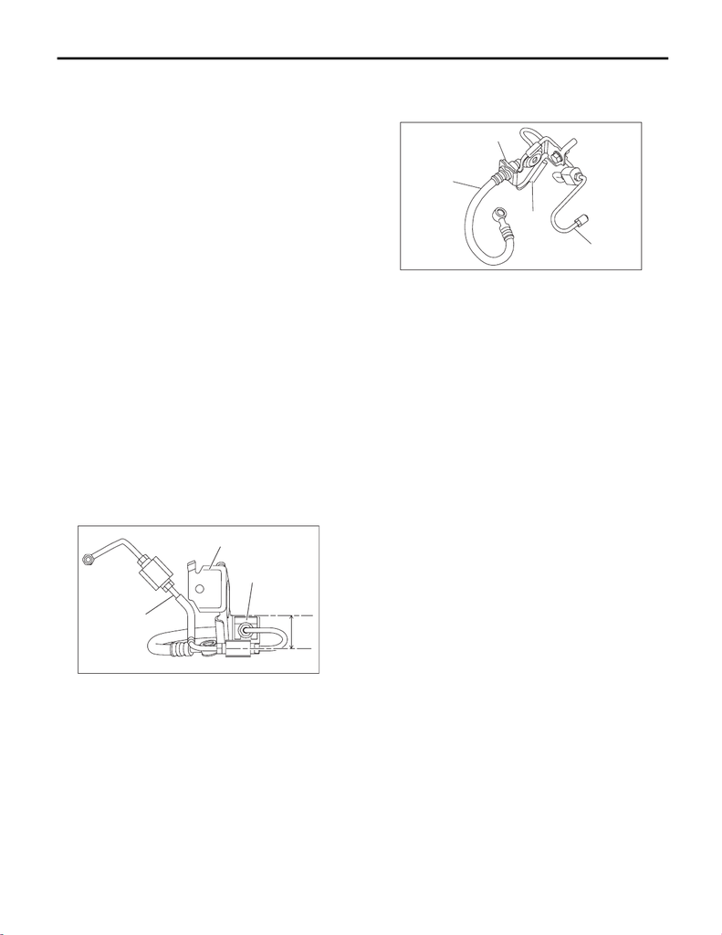

CL-27

Clutch Pipe and Hose

CLUTCH SYSTEM

7. Clutch Pipe and Hose

A: REMOVAL

1) Disconnect the ground cable from battery. <Ref.

to NT-5, BATTERY, NOTE, Note.>

NOTE:

For models other than STI model, disconnect the

ground terminal from battery sensor.

2) Remove the intercooler. <Ref. to IN(STI)-13,

REMOVAL, Intercooler.> <Ref. to IN(w/o STI)-38,

REMOVAL, Intercooler.>

3) Drain the clutch fluid. <Ref. to CL-28, Clutch Flu-

id.>

4) Remove the clutch pipe from the master cylin-

der.

5) Disconnect the hose from operating cylinder.

6) Remove the clutch bracket from the bulkhead.

7) Remove the clutch pipe from the clutch hose.

B: INSTALLATION

NOTE:

Be sure to install the clutch hose with the mark side

facing towards vehicle top.

2) Connect the clutch pipe to the clutch hose.

Tightening torque:

15 N·m (1.5 kgf-m, 11.1 ft-lb)

3) Attach the clutch bracket to the bulkhead.

Tightening torque:

25 N·m (2.5 kgf-m, 18.4 ft-lb)

4) Connect the clutch hose to the operating cylin-

der.

NOTE:

• Use a new gasket.

• Be sure to install the clutch hose with the mark

side facing upward.

• Be careful not to twist the clutch hose during in-

stallation.

Tightening torque:

18 N·m (1.8 kgf-m, 13.3 ft-lb)

5) Connect the clutch pipes to the master cylinder.

Tightening torque:

15 N·m (1.5 kgf-m, 11.1 ft-lb)

6) Bleed air from the clutch fluid. <Ref. to CL-29,

Clutch Fluid Air Bleeding.>

7) Install the intercooler. <Ref. to IN(STI)-13, RE-

MOVAL, Intercooler.> <Ref. to IN(w/o STI)-38, RE-

MOVAL, Intercooler.>

C: INSPECTION

Check the pipes and hoses for breaks and dam-

age. Check joints for fluid leakage. If crack, break-

age or damage is found, repair or replace the faulty

pipe or hose.

(A) Clutch bracket

(B) Clutch pipe

(C) Clip

(1) Attach the clutch pipe in parallel to the clutch

bracket as shown in the figure.

CL-01024

(C)

(A)

(1)

(B)

(A) Clutch pipe

(B) Clip

(C) Clutch hose

(D) Clutch bracket

CL-01046

(B)

(D)

(A)

(C)